# {introverse} quick docs

`ggplot2::geom_col()`  
**`get_help()` docs**

### Description

The [`geom_col()`](https://ggplot2.tidyverse.org/reference/geom_bar.html) function is part of the [`{ggplot2}`](https://ggplot2.tidyverse.org/) package, which is part of the [`{tidyverse}`](https://www.tidyverse.org/).

The `geom_col()` function is used within `{ggplot2}` plots to create barplots where the bar heights’ are directly taken from a variable in the dataset.

To instead plot bars whose heights are equal to *the counted number of categories*, it is recommended to use `ggplot2::geom_bar()`.

#### Required aesthetics:

- `x`: A categorical variable to visualize bars across
- `y`: A variable that determines the height of the bars
  - Note that these can be switched for a horizontal bar plot

#### Commonly used optional aesthetics:

- `color` (`colour`): The outline color for the bars
- `fill`: The fill for the bars
- `size`: The width of the bar outlines

To use this function, you need to either first load the `{ggplot2}` library, or always use the function with `ggplot2::geom_col()` notation.

```r
# Load the library
library(ggplot2)
# Or, load the full tidyverse:
library(tidyverse)

# Or, use :: notation
ggplot2::geom_col()
```

### Examples

The examples below use the `carnivores` dataset. Learn more about this dataset with `get_help("carnivores")`.

```r
# Show the carnivores dataset
carnivores
```

```
## # A tibble: 9 × 4
##   name              genus        awake brainwt
##   <chr>             <fct>        <dbl>   <dbl>
## 1 Arctic fox        Vulpes        11.5  0.0445
## 2 Cheetah           Acinonyx      11.9 NA
## 3 Dog               Canis         13.9  0.07
## 4 Gray seal         Haliochoerus  17.8  0.325
## 5 Jaguar            Panthera      13.6  0.157
## 6 Lion              Panthera      10.5 NA
## 7 Northern fur seal Callorhinus   15.3 NA
## 8 Red fox           Vulpes        14.2  0.0504
## 9 Tiger             Panthera       8.2 NA
```

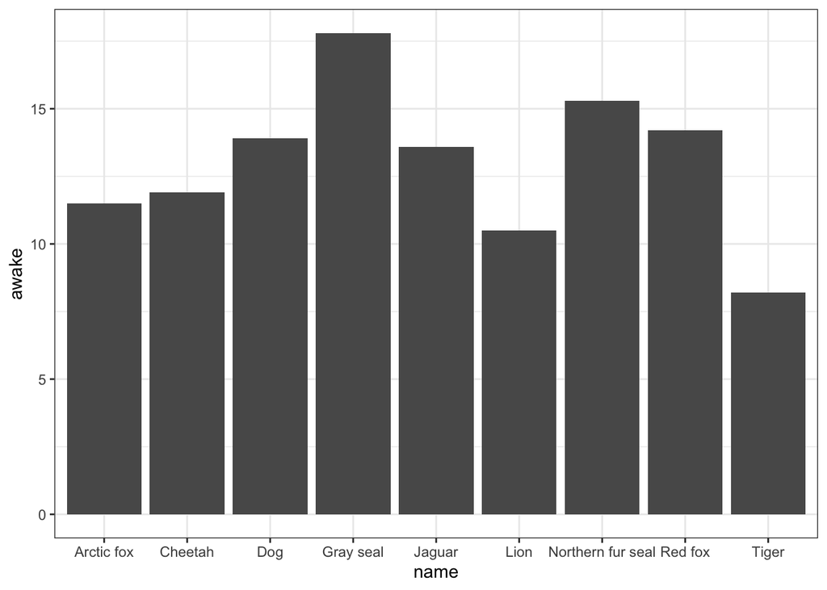

```r
# Plot the literal values of `awake` for each mammal in the carnivores dataset
ggplot(carnivores) +
  aes(x = name, y = awake) +
  geom_col()
```

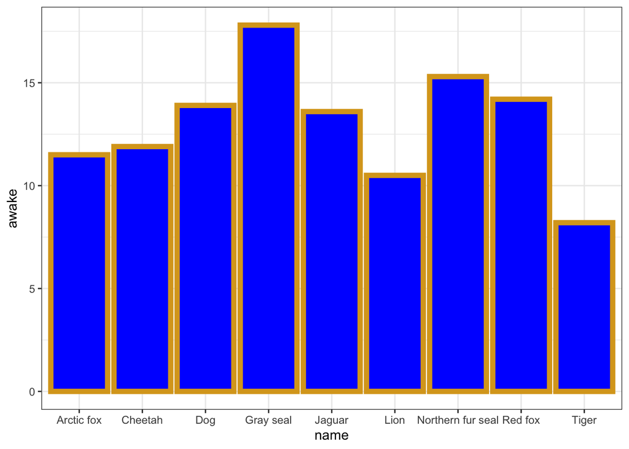

```r
# Plot the literal values of `awake` for each mammal in the carnivores dataset, with additional stylings
ggplot(carnivores) +
  aes(x = name, y = awake) +
  geom_col(color = "goldenrod",
           size = 2,
           fill = "blue")
```

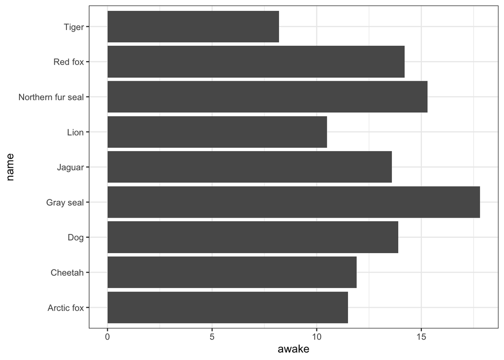

```r
# Horizontally plot the literal values of `awake` for each mammal in the carnivores dataset
ggplot(carnivores) +
  aes(x = awake, y = name) + # note that these were switched to make it horizontal
  geom_col()
```

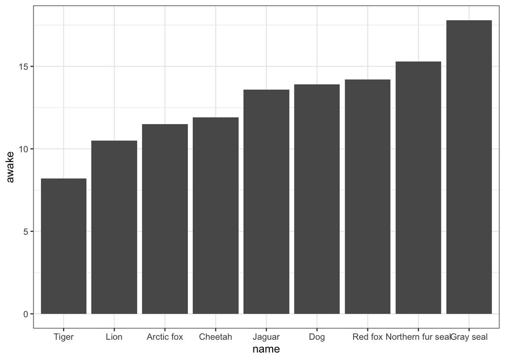

```r
# Use forcats::fct_reorder() to order the names by their awake values for a cleaner look
# It best practice to also update the x-axis title when using forcats::fct_reorder()
ggplot(carnivores) +
  aes(x = fct_reorder(name, awake),
      y = awake) +
  geom_col() +
  labs(x = "name")
```